# Algorithms Chapter 1

# Fibonnaci

Each number in the Fibonacci sequence is the sum of its two predecessors. 0, 1, 1, 2, 3, 5, 8, 13, 21, 34. It grows almost exponentially. A simple but very slow algorithm to calculate the n th position of the sequence would be an exponential implementation.

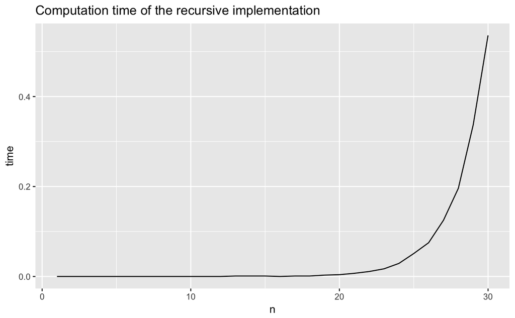

An algorithm may yield the correct result, but if it is too slow it is useless. Therefore we measure the time it takes as a function of n. We always hope that we can do better.

With the current implementation the number of computer steps needed is larger than the actual value at n. Making this useless, the computation time increases exponentially. No matter the increase in computer power, large number will never be computer within a lifetime. Expontial increase with n is very bad news, will never be efficient.

Already a better idea is storing the intermediate results.

```r
fib_exp_stored(200)
```

```
[1] 1.734025e+41
```

This is linear in n, because it takes one single step at each point in the loop. (Actually for large numbers it takes more computations, because of the addition of very large numbers).

Big O notation is the standard for expressing an algorithms efficiency. It is the rough number of computer steps as a function of n. This way it is machine independent. We are not too precise in this, because it distracts. Only the part that determine the lions share of the computation time is reported. See for exact definition page 15.